# 635 Final Project (Eileen’s part)

Eileen Yang

4/23/2021

```r
library(tidyverse)
library(rlang)
library(reshape)
library(reshape2)
library(caret)
library(factoextra)
library(gtsummary)
library(flextable)
library(pROC)
library(glmnet)
library(broom)
library(gt)
library(caret)
library(GGally)
library(mgcv)
library(splines)
```

Read in data

```r
food <-  read_csv("/Users/eileenyang/Desktop/R/BIOS 635/final-project-group-6-1-main/data/Food_Supply_kcal_Data.csv") %>%
  #first removing variables that aren't of interest (ie. not relevant, not a food group, or are unlikely to have an real impact)
  select(-Recovered, -Active, -`Unit (all except Population)`, -Obesity, -Undernourished, -Miscellaneous, -Spices, -Country) %>%
  drop_na() %>%
  #cases are per 100,000,000 people
  mutate(Cases_per_capita = Confirmed/Population * 100000000, Deaths_per_capita = Deaths/Population * 100000000) %>%
  #creating a column that specifies whether each country falls above or below the median
  mutate(Cases_vs_median = ifelse(Cases_per_capita > median(Cases_per_capita), "Above", "Below"), Deaths_vs_median = ifelse(Deaths_per_capita > median(Deaths_per_capita), "Above", "Below"))
food$Cases_vs_median <- as.factor(food$Cases_vs_median)
food$Deaths_vs_median <- as.factor(food$Deaths_vs_median)

food <- select(food,  -c("Confirmed","Deaths", "Population"))

food_cases <- select(food,  -c("Deaths_per_capita","Deaths_vs_median"))
food_deaths <- select(food,  -c("Cases_per_capita","Cases_vs_median"))
```

Summarize data

```r
#remove country for data summary
foodcols <- colnames(food)
foodcols <- foodcols[-1]

#summary for cases_vs_median:
tbl1 <- tbl_summary(data=food_cases, by=Cases_vs_median, include=colnames(food_cases), statistic = list(all_continuous() ~ "{mean} ({sd})"))

tbl2 <- tbl1 %>% add_p(test = list(all_continuous() ~ "aov")) %>% add_n()
tbl2_flex <- as_flex_table(tbl2)  %>% bold(part="header")
tbl2_flex
```

| Characteristic | N | Above, N = 821 | Below, N = 821 | p-value2 |
| --- | --- | --- | --- | --- |
| Alcoholic Beverages | 164 | 1.81 (1.11) | 0.87 (0.78) | <0.001 |
| Animal Products | 164 | 11.7 (3.9) | 6.9 (4.3) | <0.001 |
| Animal fats | 164 | 1.73 (1.44) | 0.82 (0.96) | <0.001 |
| Aquatic Products, Other | 164 |  |  | 0.12 |
| 0 |  | 82 (100%) | 78 (95%) |  |
| 0.0185 |  | 0 (0%) | 1 (1.2%) |  |
| 0.0209 |  | 0 (0%) | 1 (1.2%) |  |
| 0.0336 |  | 0 (0%) | 1 (1.2%) |  |
| 0.4007 |  | 0 (0%) | 1 (1.2%) |  |
| Cereals - Excluding Beer | 164 | 18 (5) | 23 (7) | <0.001 |
| Eggs | 164 | 0.52 (0.26) | 0.34 (0.33) | <0.001 |
| Fish, Seafood | 164 | 0.65 (0.61) | 0.57 (0.49) | 0.4 |
| Fruits - Excluding Wine | 164 | 2.27 (1.45) | 1.79 (1.39) | 0.031 |
| Meat | 164 | 4.66 (1.81) | 3.03 (2.26) | <0.001 |
| Milk - Excluding Butter | 164 | 3.95 (1.80) | 1.96 (1.73) | <0.001 |
| Offals | 164 | 0.15 (0.09) | 0.14 (0.13) | 0.6 |
| Oilcrops | 164 | 0.68 (0.81) | 1.40 (1.81) | 0.001 |
| Pulses | 164 | 0.78 (0.71) | 1.45 (1.49) | <0.001 |
| Starchy Roots | 164 | 2.1 (2.3) | 4.1 (4.9) | 0.001 |
| Stimulants | 164 | 0.46 (0.35) | 0.15 (0.16) | <0.001 |
| Sugar Crops | 164 | 0.00 (0.01) | 0.03 (0.10) | 0.004 |
| Sugar & Sweeteners | 164 | 5.73 (1.66) | 4.01 (2.19) | <0.001 |
| Treenuts | 164 | 0.30 (0.29) | 0.23 (0.29) | 0.084 |
| Vegetal Products | 164 | 38.3 (3.9) | 43.1 (4.3) | <0.001 |
| Vegetable Oils | 164 | 5.00 (2.15) | 4.80 (2.23) | 0.6 |
| Vegetables | 164 | 1.20 (0.62) | 0.97 (0.67) | 0.024 |
| Cases_per_capita | 164 | 173 (279) | 2 (2) | <0.001 |

1Mean (SD); n (%)  
2One-way ANOVA; Fisher's exact test

```r
#summary for cases and deaths_vs_median:
tbl1 <- tbl_summary(data=food_deaths, by=Deaths_vs_median, include=colnames(food_deaths), statistic = list(all_continuous() ~ "{mean} ({sd})"))

tbl2 <- tbl1 %>% add_p(test = list(all_continuous() ~ "aov")) %>% add_n()
tbl2_flex <- as_flex_table(tbl2)  %>% bold(part="header")
tbl2_flex
```

| Characteristic | N | Above, N = 821 | Below, N = 821 | p-value2 |
| --- | --- | --- | --- | --- |
| Alcoholic Beverages | 164 | 1.80 (1.12) | 0.89 (0.79) | <0.001 |
| Animal Products | 164 | 11.7 (4.0) | 6.9 (4.2) | <0.001 |
| Animal fats | 164 | 1.76 (1.46) | 0.79 (0.89) | <0.001 |
| Aquatic Products, Other | 164 |  |  | 0.12 |
| 0 |  | 82 (100%) | 78 (95%) |  |
| 0.0185 |  | 0 (0%) | 1 (1.2%) |  |
| 0.0209 |  | 0 (0%) | 1 (1.2%) |  |
| 0.0336 |  | 0 (0%) | 1 (1.2%) |  |
| 0.4007 |  | 0 (0%) | 1 (1.2%) |  |
| Cereals - Excluding Beer | 164 | 18 (5) | 23 (7) | <0.001 |
| Eggs | 164 | 0.53 (0.26) | 0.33 (0.32) | <0.001 |
| Fish, Seafood | 164 | 0.64 (0.61) | 0.58 (0.49) | 0.4 |
| Fruits - Excluding Wine | 164 | 2.13 (1.38) | 1.93 (1.49) | 0.4 |
| Meat | 164 | 4.58 (1.85) | 3.11 (2.28) | <0.001 |
| Milk - Excluding Butter | 164 | 3.99 (1.79) | 1.92 (1.69) | <0.001 |
| Offals | 164 | 0.14 (0.08) | 0.14 (0.13) | 0.9 |
| Oilcrops | 164 | 0.68 (0.91) | 1.40 (1.75) | 0.001 |
| Pulses | 164 | 0.75 (0.64) | 1.48 (1.50) | <0.001 |
| Starchy Roots | 164 | 2.0 (2.2) | 4.3 (4.9) | <0.001 |
| Stimulants | 164 | 0.45 (0.35) | 0.16 (0.16) | <0.001 |
| Sugar Crops | 164 | 0.00 (0.01) | 0.03 (0.10) | 0.004 |
| Sugar & Sweeteners | 164 | 5.73 (1.63) | 4.01 (2.22) | <0.001 |
| Treenuts | 164 | 0.30 (0.28) | 0.23 (0.30) | 0.11 |
| Vegetal Products | 164 | 38.3 (4.0) | 43.1 (4.2) | <0.001 |
| Vegetable Oils | 164 | 5.15 (2.18) | 4.65 (2.17) | 0.14 |
| Vegetables | 164 | 1.19 (0.62) | 0.97 (0.67) | 0.034 |
| Deaths_per_capita | 164 | 2.42 (3.82) | 0.03 (0.04) | <0.001 |

1Mean (SD); n (%)  
2One-way ANOVA; Fisher's exact test

```r
#######################

#summary for cases per capita:
tbl1 <- tbl_summary(data=food, include=colnames(food), statistic = list(all_continuous() ~ "{mean} ({sd})"))

tbl2 <- tbl1  %>% add_n()
tbl2_flex <- as_flex_table(tbl2)  %>% bold(part="header")
tbl2_flex
```

| Characteristic | N | N = 1641 |
| --- | --- | --- |
| Alcoholic Beverages | 164 | 1.34 (1.07) |
| Animal Products | 164 | 9.3 (4.8) |
| Animal fats | 164 | 1.28 (1.30) |
| Aquatic Products, Other | 164 |  |
| 0 |  | 160 (98%) |
| 0.0185 |  | 1 (0.6%) |
| 0.0209 |  | 1 (0.6%) |
| 0.0336 |  | 1 (0.6%) |
| 0.4007 |  | 1 (0.6%) |
| Cereals - Excluding Beer | 164 | 20 (6) |
| Eggs | 164 | 0.43 (0.31) |
| Fish, Seafood | 164 | 0.61 (0.55) |
| Fruits - Excluding Wine | 164 | 2.03 (1.44) |
| Meat | 164 | 3.84 (2.20) |
| Milk - Excluding Butter | 164 | 2.96 (2.02) |
| Offals | 164 | 0.14 (0.11) |
| Oilcrops | 164 | 1.04 (1.44) |
| Pulses | 164 | 1.11 (1.21) |
| Starchy Roots | 164 | 3.1 (4.0) |
| Stimulants | 164 | 0.30 (0.31) |
| Sugar Crops | 164 | 0.02 (0.07) |
| Sugar & Sweeteners | 164 | 4.87 (2.12) |
| Treenuts | 164 | 0.26 (0.29) |
| Vegetal Products | 164 | 40.7 (4.8) |
| Vegetable Oils | 164 | 4.90 (2.18) |
| Vegetables | 164 | 1.08 (0.65) |
| Cases_per_capita | 164 | 87 (215) |
| Deaths_per_capita | 164 | 1.22 (2.95) |
| Cases_vs_median | 164 |  |
| Above |  | 82 (50%) |
| Below |  | 82 (50%) |
| Deaths_vs_median | 164 |  |
| Above |  | 82 (50%) |
| Below |  | 82 (50%) |

1Mean (SD); n (%)

## Correlations

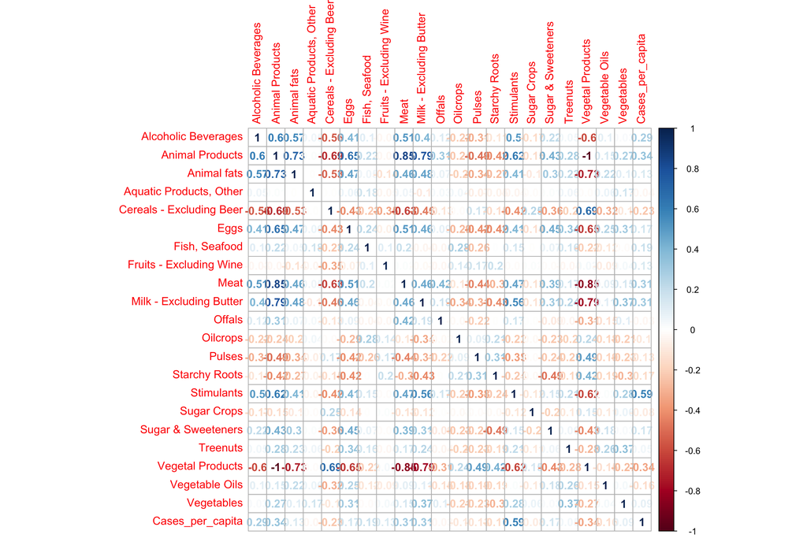

```r
#First, some correlation plots to see correlations
food_cases_num <- food_cases[,-23]
foodcases_corr <- cor(food_cases_num)
corrp <- corrplot::corrplot(foodcases_corr, method="number")
```

- It would make sense to remove some of these variables–perhaps removing Animal Products and Vegetal Products would be beneficial. **(or even more of the animal-related variables?)**

# Continuous Outcomes - Cases

**note I had to remove Aquatic Products, Other for now bc it was giving me some issues** With collinear variables removed (Animal Products, Vegetal Products)

```r
food_cases2 <- select(food_cases, -c("Cases_vs_median","Aquatic Products, Other", "Animal Products","Vegetal Products"))
```

## KNN regression (10 fold)

```r
set.seed(12)

  folds <- createFolds(y=food_cases2$Cases_per_capita, k=10)
  foldnum <- list()
  mselist <- list()

  for(f in 1:length(folds)){
    foldnum[f] <- paste("Fold", f)
    foodcases_train <- food_cases2[-folds[[f]],]
    foodcases_test <- food_cases2[folds[[f]],]
    knn_train <- train(form=`Cases_per_capita` ~., data=foodcases_train,
                       method="knn", tuneLength = 20, preProcess=c("scale", "center"))
    foodcases_pred <- predict(knn_train, newdata=foodcases_test)
    mselist[f] <- mean((foodcases_test$`Cases_per_capita` - foodcases_pred) ^ 2)

    }
error_knn <- mean(unlist(mselist))
sd_knn <- sd(unlist(mselist))
error_knn
```

```
## [1] 36504.56
```

```r
sd_knn
```

```
## [1] 44787.56
```

## Linear Regression

First check assumptions **Actually doesn’t seem to meet lin regression assumptions…so might take this part out**

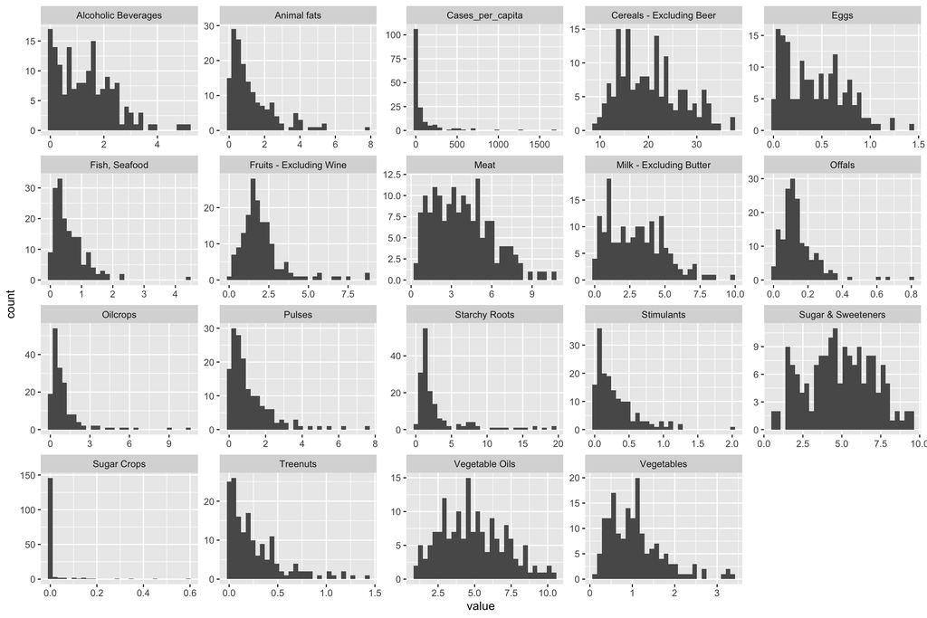

```r
food_cases2 %>%
  keep(is.numeric) %>%
  gather() %>%
  ggplot(aes(value)) +
    facet_wrap(~ key, scales = "free") +
    geom_histogram()
```

```r
#removing outliers
#length(which(food_cases2$Cases_per_capita > 500))
#mean(food_cases2$Cases_per_capita)
#hist(food_cases2[food_cases2$Cases_per_capita < 500,]$`Cases_per_capita`)

food_cases2_outlier_rm <- food_cases2[food_cases2$Cases_per_capita < 500,]


#melt your data
foodcases_melt <- melt(food_cases2_outlier_rm,"Cases_per_capita")
head(foodcases_melt)
```

```
##   Cases_per_capita            variable  value
## 1        0.3651207 Alcoholic Beverages 0.0000
## 2      104.5560577 Alcoholic Beverages 0.9120
## 3        0.5521047 Alcoholic Beverages 0.0896
## 4        0.1896792 Alcoholic Beverages 1.9388
## 5      299.8750521 Alcoholic Beverages 2.3041
## 6        9.5999017 Alcoholic Beverages 1.4354
```

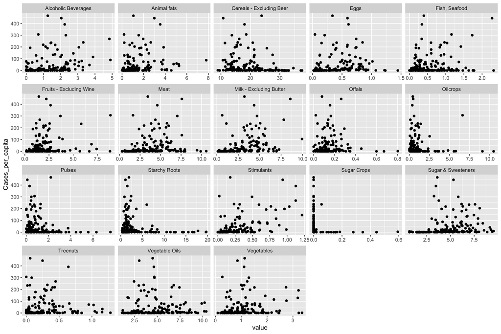

```r
#scatterplot per group
ggplot(foodcases_melt, aes(x=value, y=Cases_per_capita)) +
  geom_point() +
  facet_wrap(.~variable, scales = "free_x")
```

10 fold CV

```r
set.seed(12)

folds <- createFolds(y=food_cases2$Cases_per_capita, k=10)
  foldnum <- list()
  mselist2 <- list()

for(f in 1:length(folds)){
    foldnum[f] <- paste("Fold", f)
    foodcases_train <- food_cases2[-folds[[f]],]
    foodcases_test <- food_cases2[folds[[f]],]
    lm_train <- lm(`Cases_per_capita` ~., data=foodcases_train)
    foodcases_pred <- predict(lm_train, newdata=foodcases_test)
    mselist2[f] <- mean((foodcases_test$`Cases_per_capita` - foodcases_pred) ^ 2)
}
error_lin <- mean(unlist(mselist2))
sd_lin <- sd(unlist(mselist2))
error_lin
```

```
## [1] 32084.33
```

```r
sd_lin
```

```
## [1] 29445.35
```

## Lasso vs linear regression - holdout method to see which variables would be removed

```r
food_cases2_forlasso <- select(food_cases, -c("Cases_vs_median","Aquatic Products, Other"))

set.seed(12)

#From Lasso
foodcases_lasso_full <- cv.glmnet(x = as.matrix(food_cases2_forlasso[, -21]), y = food_cases2$Cases_per_capita, alpha = 1)
tmp_coeffs <- coef(foodcases_lasso_full, s=foodcases_lasso_full$lambda.min)
data.frame(name = tmp_coeffs@Dimnames[[1]][tmp_coeffs@i + 1], coefficient = tmp_coeffs@x)
```

```
##                       name coefficient
## 1              (Intercept)   24.425406
## 2              Animal fats   -9.383192
## 3                     Eggs   -5.330560
## 4            Fish, Seafood   10.335366
## 5  Fruits - Excluding Wine   11.806396
## 6                     Meat    7.416575
## 7                   Offals -239.493382
## 8                   Pulses    2.196089
## 9            Starchy Roots   -1.835039
## 10              Stimulants  389.774437
## 11      Sugar & Sweeteners    3.691359
## 12          Vegetable Oils  -14.104946
## 13              Vegetables  -11.087194
```

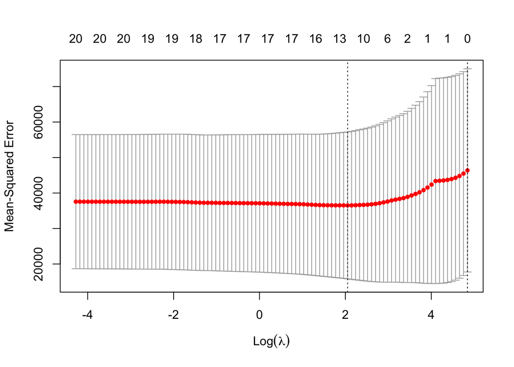

```r
plot(foodcases_lasso_full)
```

```r
#From Linear Regression
foodcases_lm_full <- lm(Cases_per_capita ~., data=food_cases2_forlasso)
summary(foodcases_lm_full)
```

```
##
## Call:
## lm(formula = Cases_per_capita ~ ., data = food_cases2_forlasso)
##
## Residuals:
##     Min      1Q  Median      3Q     Max
## -442.88  -65.55   -7.50   46.83 1118.02
##
## Coefficients:
##                            Estimate Std. Error t value Pr(>|t|)
## (Intercept)                -5667.51   61304.58  -0.092   0.9265
## `Alcoholic Beverages`        -71.48      52.12  -1.371   0.1724
## `Animal Products`            169.03    1201.99   0.141   0.8884
## `Animal fats`                -72.39     426.71  -0.170   0.8655
## `Cereals - Excluding Beer`   -74.77      47.56  -1.572   0.1182
## Eggs                        -119.23     428.93  -0.278   0.7814
## `Fish, Seafood`              -38.60     434.33  -0.089   0.9293
## `Fruits - Excluding Wine`    -59.58      48.89  -1.219   0.2250
## Meat                         -38.45     427.31  -0.090   0.9284
## `Milk - Excluding Butter`    -52.92     425.17  -0.124   0.9011
## Offals                      -399.37     459.49  -0.869   0.3862
## Oilcrops                     -82.91      47.96  -1.729   0.0860 .
## Pulses                       -65.47      50.58  -1.294   0.1976
## `Starchy Roots`              -80.12      47.30  -1.694   0.0925 .
## Stimulants                   329.87      78.80   4.186 4.93e-05 ***
## `Sugar Crops`               -171.60     209.04  -0.821   0.4131
## `Sugar & Sweeteners`         -72.81      49.20  -1.480   0.1411
## Treenuts                     -99.76      73.49  -1.358   0.1767
## `Vegetal Products`           188.86    1217.90   0.155   0.8770
## `Vegetable Oils`             -89.66      47.57  -1.885   0.0615 .
## Vegetables                  -100.42      54.90  -1.829   0.0695 .
## ---
## Signif. codes:  0 '***' 0.001 '**' 0.01 '*' 0.05 '.' 0.1 ' ' 1
##
## Residual standard error: 165.3 on 143 degrees of freedom
## Multiple R-squared:  0.4801, Adjusted R-squared:  0.4074
## F-statistic: 6.603 on 20 and 143 DF,  p-value: 1.867e-12
```

- It looks like 12 variables are kept in the model, with 8 removed: Alcoholic Beverages, Animal Products, Cereals - excluding Beer, Milk - Excluding Butter, Oilcrops, Sugar Crops, Treenuts, and Vegetal Products.

## Lasso (10-fold):

```r
set.seed(12)
folds <- createFolds(y=food_cases2_forlasso$Cases_per_capita, k=10)
  foldnum <- list()
  mselist2 <- list()

  for(f in 1:length(folds)){
    foldnum[f] <- paste("Fold", f)
    foodcases_train <- food_cases2_forlasso[-folds[[f]],]
    foodcases_test <- food_cases2_forlasso[folds[[f]],]

    foodcases_lasso1 <- cv.glmnet(x=as.matrix(foodcases_train[,-21]), y=foodcases_train$Cases_per_capita, alpha=1)
    opt_lambda <- foodcases_lasso1$lambda.min

    foodcases_pred <-  predict(foodcases_lasso1, newx=as.matrix(foodcases_test[,-21]), s=opt_lambda)
    mselist2[f] <- mean((foodcases_test$Cases_per_capita - foodcases_pred) ^ 2)

  }
error_lasso <- mean(unlist(mselist2))
sd_lasso <- sd(unlist(mselist2))

error_lasso
```

```
## [1] 31835.49
```

```r
sd_lasso
```

```
## [1] 31126.87
```

Ridge - 10 fold

```r
set.seed(12)
folds <- createFolds(y=food_cases2_forlasso$Cases_per_capita, k=10)
  foldnum <- list()
  mselist2 <- list()

  for(f in 1:length(folds)){
    foldnum[f] <- paste("Fold", f)
    foodcases_train <- food_cases2_forlasso[-folds[[f]],]
    foodcases_test <- food_cases2_forlasso[folds[[f]],]

    foodcases_ridge1 <- cv.glmnet(x=as.matrix(foodcases_train[,-21]), y=foodcases_train$Cases_per_capita, alpha=0)
    opt_lambda <- foodcases_ridge1$lambda.min

    foodcases_pred <-  predict(foodcases_ridge1, newx=as.matrix(foodcases_test[,-21]), s=opt_lambda)
    mselist2[f] <- mean((foodcases_test$Cases_per_capita - foodcases_pred) ^ 2)

  }
error_ridge <- mean(unlist(mselist2))
sd_ridge <- sd(unlist(mselist2))

error_ridge
```

```
## [1] 31905.24
```

```r
sd_ridge
```

```
## [1] 32849.18
```

# Continuous Outcomes - Deaths

**note I had to remove Aquatic Products, Other for now bc it was giving me some issues** With collinear variables removed (Animal Products, Vegetal Products)

```r
food_deaths2 <- select(food_deaths, -c("Deaths_vs_median","Aquatic Products, Other", "Animal Products","Vegetal Products"))
```

## KNN regression (10 fold)

```r
set.seed(12)

  folds <- createFolds(y=food_deaths2$Deaths_per_capita, k=10)
  foldnum <- list()
  mselist <- list()

  for(f in 1:length(folds)){
    foldnum[f] <- paste("Fold", f)
    fooddeaths_train <- food_deaths2[-folds[[f]],]
    fooddeaths_test <- food_deaths2[folds[[f]],]
    knn_train <- train(form=`Deaths_per_capita` ~., data=fooddeaths_train,
                       method="knn", tuneLength = 20, preProcess=c("scale", "center"))
    fooddeaths_pred <- predict(knn_train, newdata=fooddeaths_test)
    mselist[f] <- mean((fooddeaths_test$`Deaths_per_capita` - fooddeaths_pred) ^ 2)

    }
error_knn <- mean(unlist(mselist))
sd_knn <- sd(unlist(mselist))
error_knn
```

```
## [1] 7.225715
```

```r
sd_knn
```

```
## [1] 8.120621
```

## Linear Regression

First check assumptions **Actually doesn’t seem to meet lin regression assumptions…so might take this part out**

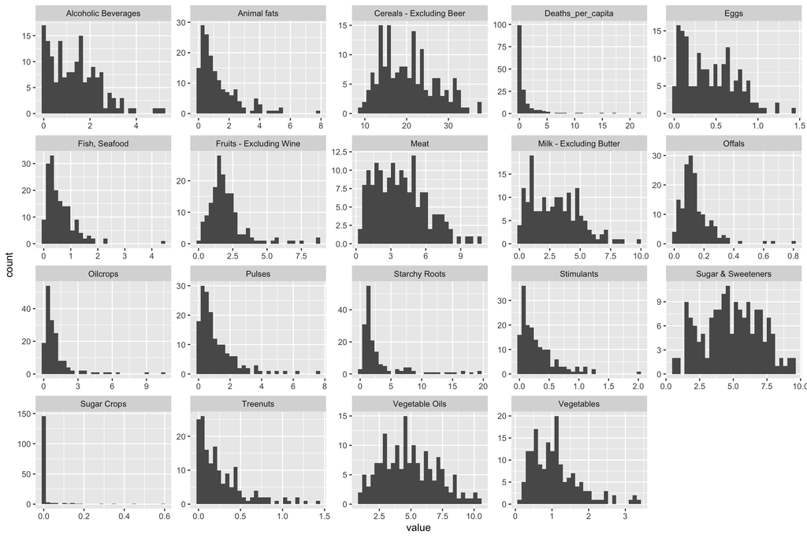

```r
food_deaths2 %>%
  keep(is.numeric) %>%
  gather() %>%
  ggplot(aes(value)) +
    facet_wrap(~ key, scales = "free") +
    geom_histogram()
```

```r
#removing outliers
#length(which(food_deaths2$Deaths_per_capita > 15))
#median(food_deaths2$Deaths_per_capita)

food_deaths2_outlier_rm <- food_deaths2[food_deaths2$Deaths_per_capita < 15,]


#melt your data
fooddeaths_melt <- melt(food_deaths2_outlier_rm,"Deaths_per_capita")
head(fooddeaths_melt)
```

```
##   Deaths_per_capita            variable  value
## 1       0.015890307 Alcoholic Beverages 0.0000
## 2       1.795326787 Alcoholic Beverages 0.9120
## 3       0.014784934 Alcoholic Beverages 0.0896
## 4       0.004490959 Alcoholic Beverages 1.9388
## 5       7.288629738 Alcoholic Beverages 2.3041
## 6       0.238505487 Alcoholic Beverages 1.4354
```

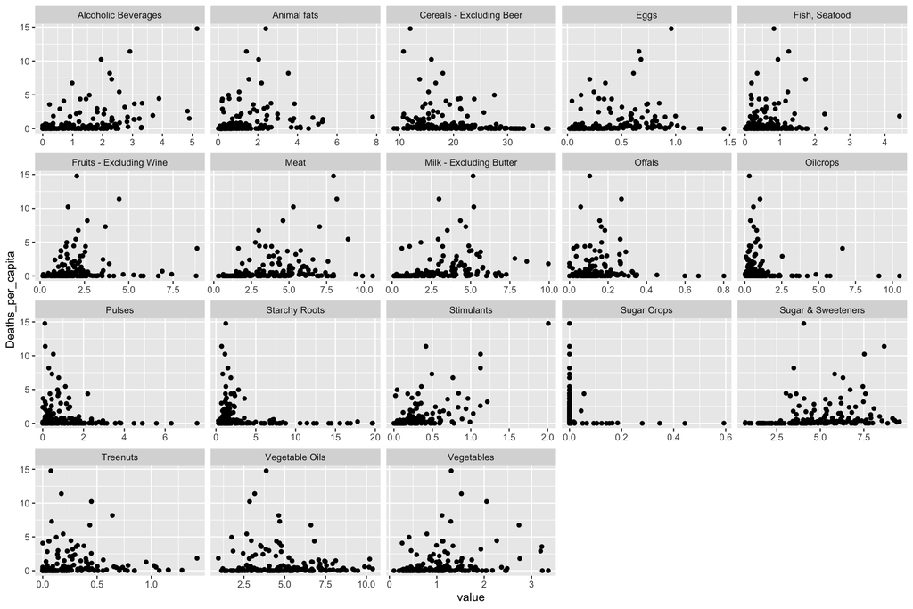

```r
#scatterplot per group
ggplot(fooddeaths_melt, aes(x=value, y=Deaths_per_capita)) +
  geom_point() +
  facet_wrap(.~variable, scales = "free_x")
```

10 fold CV

```r
set.seed(12)

folds <- createFolds(y=food_deaths2$Deaths_per_capita, k=10)
  foldnum <- list()
  mselist2 <- list()

for(f in 1:length(folds)){
    foldnum[f] <- paste("Fold", f)
    fooddeaths_train <- food_deaths2[-folds[[f]],]
    fooddeaths_test <- food_deaths2[folds[[f]],]
    lm_train <- lm(`Deaths_per_capita` ~., data=fooddeaths_train)
    fooddeaths_pred <- predict(lm_train, newdata=fooddeaths_test)
    mselist2[f] <- mean((fooddeaths_test$`Deaths_per_capita` - fooddeaths_pred) ^ 2)
}
error_lin <- mean(unlist(mselist2))
sd_lin <- sd(unlist(mselist2))
error_lin
```

```
## [1] 7.036242
```

```r
sd_lin
```

```
## [1] 6.884031
```

## Lasso vs linear regression - holdout method to see which variables would be removed

```r
food_deaths2_forlasso <- select(food_deaths, -c("Deaths_vs_median","Aquatic Products, Other"))

set.seed(12)

#From Lasso
fooddeaths_lasso_full <- cv.glmnet(x = as.matrix(food_deaths2_forlasso[, -21]), y = food_deaths2$Deaths_per_capita, alpha = 1)
tmp_coeffs <- coef(fooddeaths_lasso_full, s=fooddeaths_lasso_full$lambda.min)
data.frame(name = tmp_coeffs@Dimnames[[1]][tmp_coeffs@i + 1], coefficient = tmp_coeffs@x)
```

```
##                       name coefficient
## 1              (Intercept)  0.24047060
## 2      Alcoholic Beverages  0.15593949
## 3                     Eggs -0.55115069
## 4            Fish, Seafood -0.02415531
## 5  Fruits - Excluding Wine  0.16398568
## 6                     Meat  0.00368985
## 7                   Offals -2.30234093
## 8            Starchy Roots -0.04274633
## 9               Stimulants  4.75033976
## 10             Sugar Crops -0.16882224
## 11      Sugar & Sweeteners  0.10392832
## 12                Treenuts -0.36849688
## 13          Vegetable Oils -0.14564583
```

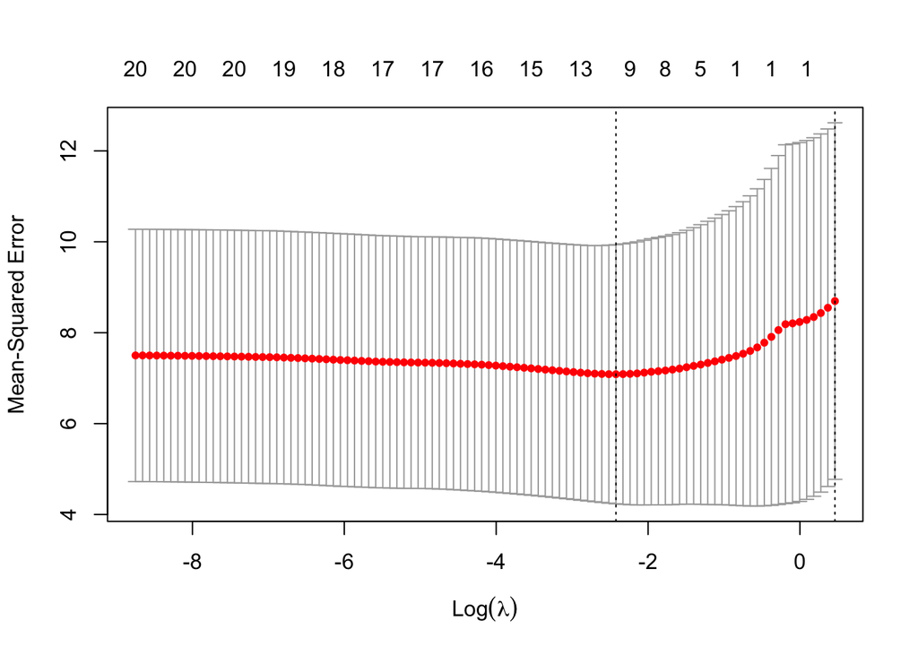

```r
plot(fooddeaths_lasso_full)
```

```r
#From Linear Regression
fooddeaths_lm_full <- lm(Deaths_per_capita ~., data=food_deaths2_forlasso)
summary(fooddeaths_lm_full)
```

```
##
## Call:
## lm(formula = Deaths_per_capita ~ ., data = food_deaths2_forlasso)
##
## Residuals:
##     Min      1Q  Median      3Q     Max
## -4.9870 -1.0784 -0.0789  0.4578 15.2759
##
## Coefficients:
##                             Estimate Std. Error t value Pr(>|t|)
## (Intercept)                -732.0114   911.6490  -0.803 0.423334
## `Alcoholic Beverages`        -0.6299     0.7751  -0.813 0.417746
## `Animal Products`            16.3693    17.8746   0.916 0.361321
## `Animal fats`                -1.6892     6.3455  -0.266 0.790466
## `Cereals - Excluding Beer`   -0.8398     0.7073  -1.187 0.237086
## Eggs                         -2.7276     6.3785  -0.428 0.669565
## `Fish, Seafood`              -2.2154     6.4588  -0.343 0.732097
## `Fruits - Excluding Wine`    -0.6183     0.7270  -0.851 0.396466
## Meat                         -1.5949     6.3544  -0.251 0.802176
## `Milk - Excluding Butter`    -1.8033     6.3227  -0.285 0.775893
## Offals                       -5.6984     6.8330  -0.834 0.405699
## Oilcrops                     -0.8306     0.7133  -1.165 0.246145
## Pulses                       -0.7901     0.7521  -1.050 0.295276
## `Starchy Roots`              -0.9142     0.7034  -1.300 0.195766
## Stimulants                    4.1193     1.1718   3.515 0.000589 ***
## `Sugar Crops`                -2.2745     3.1085  -0.732 0.465553
## `Sugar & Sweeteners`         -0.7438     0.7316  -1.017 0.311004
## Treenuts                     -1.5434     1.0928  -1.412 0.160026
## `Vegetal Products`           15.4878    18.1111   0.855 0.393897
## `Vegetable Oils`             -1.0139     0.7074  -1.433 0.153925
## Vegetables                   -0.7851     0.8164  -0.962 0.337827
## ---
## Signif. codes:  0 '***' 0.001 '**' 0.01 '*' 0.05 '.' 0.1 ' ' 1
##
## Residual standard error: 2.459 on 143 degrees of freedom
## Multiple R-squared:  0.3894, Adjusted R-squared:  0.304
## F-statistic: 4.559 on 20 and 143 DF,  p-value: 3.006e-08
```

## Lasso (10-fold):

```r
set.seed(12)
folds <- createFolds(y=food_deaths2_forlasso$Deaths_per_capita, k=10)
  foldnum <- list()
  mselist2 <- list()

  for(f in 1:length(folds)){
    foldnum[f] <- paste("Fold", f)
    fooddeaths_train <- food_deaths2_forlasso[-folds[[f]],]
    fooddeaths_test <- food_deaths2_forlasso[folds[[f]],]

    fooddeaths_lasso1 <- cv.glmnet(x=as.matrix(fooddeaths_train[,-21]), y=fooddeaths_train$Deaths_per_capita, alpha=1)
    opt_lambda <- fooddeaths_lasso1$lambda.min

    fooddeaths_pred <-  predict(fooddeaths_lasso1, newx=as.matrix(fooddeaths_test[,-21]), s=opt_lambda)
    mselist2[f] <- mean((fooddeaths_test$Deaths_per_capita - fooddeaths_pred) ^ 2)

  }
error_lasso <- mean(unlist(mselist2))
sd_lasso <- sd(unlist(mselist2))

error_lasso
```

```
## [1] 6.664275
```

```r
sd_lasso
```

```
## [1] 7.140828
```

Ridge - 10 fold

```r
set.seed(12)
folds <- createFolds(y=food_deaths2_forlasso$Deaths_per_capita, k=10)
  foldnum <- list()
  mselist2 <- list()

  for(f in 1:length(folds)){
    foldnum[f] <- paste("Fold", f)
    fooddeaths_train <- food_deaths2_forlasso[-folds[[f]],]
    fooddeaths_test <- food_deaths2_forlasso[folds[[f]],]

    fooddeaths_ridge1 <- cv.glmnet(x=as.matrix(fooddeaths_train[,-21]), y=fooddeaths_train$Deaths_per_capita, alpha=0)
    opt_lambda <- fooddeaths_ridge1$lambda.min

    fooddeaths_pred <-  predict(fooddeaths_ridge1, newx=as.matrix(fooddeaths_test[,-21]), s=opt_lambda)
    mselist2[f] <- mean((fooddeaths_test$Deaths_per_capita - fooddeaths_pred) ^ 2)

  }
error_ridge <- mean(unlist(mselist2))
sd_ridge <- sd(unlist(mselist2))

error_ridge
```

```
## [1] 6.808599
```

```r
sd_ridge
```

```
## [1] 7.475502
```

[output not shown]